# Risk Factor Analysis

## Outcome Variable

**Outcome Variable:** pers_wast

## Predictor Variables

**Intervention Variable:** exclfeed6

**Adjustment Set:**

- arm
- sex
- W_mage
- meducyrs
- feducyrs
- hhwealth_quart
- hfoodsec
- W_mhtcm
- vagbrth
- W_gagebrth
- W_birthwt
- W_birthlen
- W_nrooms
- W_nchldlt5
- month
- brthmon
- W_parity
- impfloor
- impsan
- safeh20
- delta_W_mage
- delta_meducyrs
- delta_feducyrs
- delta_hhwealth_quart
- delta_hfoodsec
- delta_W_mhtcm
- delta_vagbrth
- delta_W_gagebrth
- delta_W_birthwt
- delta_W_birthlen
- delta_W_nrooms
- delta_W_nchldlt5
- delta_month
- delta_brthmon
- delta_W_parity
- delta_impfloor
- delta_impsan
- delta_safeh20

## Stratifying Variables

The analysis was stratified on these variable(s):

- agecat
- studyid
- country

## Data Summary

| agecat | studyid | country | exclfeed6 | pers_wast | n_cell | n |
| --- | --- | --- | --- | --- | --- | --- |
| 0-24 months | ki0047075b-MAL-ED | BANGLADESH | 1 | 0 | 54 | 238 |
| 0-24 months | ki0047075b-MAL-ED | BANGLADESH | 1 | 1 | 4 | 238 |
| 0-24 months | ki0047075b-MAL-ED | BANGLADESH | 0 | 0 | 171 | 238 |
| 0-24 months | ki0047075b-MAL-ED | BANGLADESH | 0 | 1 | 9 | 238 |
| 0-24 months | ki0047075b-MAL-ED | BRAZIL | 1 | 0 | 17 | 212 |
| 0-24 months | ki0047075b-MAL-ED | BRAZIL | 1 | 1 | 0 | 212 |
| 0-24 months | ki0047075b-MAL-ED | BRAZIL | 0 | 0 | 193 | 212 |
| 0-24 months | ki0047075b-MAL-ED | BRAZIL | 0 | 1 | 2 | 212 |
| 0-24 months | ki0047075b-MAL-ED | INDIA | 1 | 0 | 6 | 234 |
| 0-24 months | ki0047075b-MAL-ED | INDIA | 1 | 1 | 0 | 234 |
| 0-24 months | ki0047075b-MAL-ED | INDIA | 0 | 0 | 209 | 234 |
| 0-24 months | ki0047075b-MAL-ED | INDIA | 0 | 1 | 19 | 234 |
| 0-24 months | ki0047075b-MAL-ED | NEPAL | 1 | 0 | 15 | 235 |
| 0-24 months | ki0047075b-MAL-ED | NEPAL | 1 | 1 | 0 | 235 |
| 0-24 months | ki0047075b-MAL-ED | NEPAL | 0 | 0 | 217 | 235 |
| 0-24 months | ki0047075b-MAL-ED | NEPAL | 0 | 1 | 3 | 235 |
| 0-24 months | ki0047075b-MAL-ED | PERU | 1 | 0 | 11 | 270 |
| 0-24 months | ki0047075b-MAL-ED | PERU | 1 | 1 | 0 | 270 |
| 0-24 months | ki0047075b-MAL-ED | PERU | 0 | 0 | 258 | 270 |
| 0-24 months | ki0047075b-MAL-ED | PERU | 0 | 1 | 1 | 270 |
| 0-24 months | ki0047075b-MAL-ED | SOUTH AFRICA | 1 | 0 | 0 | 248 |
| 0-24 months | ki0047075b-MAL-ED | SOUTH AFRICA | 1 | 1 | 0 | 248 |
| 0-24 months | ki0047075b-MAL-ED | SOUTH AFRICA | 0 | 0 | 246 | 248 |
| 0-24 months | ki0047075b-MAL-ED | SOUTH AFRICA | 0 | 1 | 2 | 248 |
| 0-24 months | ki0047075b-MAL-ED | TANZANIA, UNITED REPUBLIC OF | 1 | 0 | 1 | 248 |
| 0-24 months | ki0047075b-MAL-ED | TANZANIA, UNITED REPUBLIC OF | 1 | 1 | 0 | 248 |
| 0-24 months | ki0047075b-MAL-ED | TANZANIA, UNITED REPUBLIC OF | 0 | 0 | 247 | 248 |
| 0-24 months | ki0047075b-MAL-ED | TANZANIA, UNITED REPUBLIC OF | 0 | 1 | 0 | 248 |
| 0-24 months | ki1000108-CMC-V-BCS-2002 | INDIA | 1 | 0 | 19 | 19 |
| 0-24 months | ki1000108-CMC-V-BCS-2002 | INDIA | 1 | 1 | 0 | 19 |

[output cut: 170 more lines]

The following strata were considered:

- agecat: 0-24 months, studyid: ki0047075b-MAL-ED, country: BANGLADESH
- agecat: 0-24 months, studyid: ki0047075b-MAL-ED, country: BRAZIL
- agecat: 0-24 months, studyid: ki0047075b-MAL-ED, country: INDIA
- agecat: 0-24 months, studyid: ki0047075b-MAL-ED, country: NEPAL
- agecat: 0-24 months, studyid: ki0047075b-MAL-ED, country: PERU
- agecat: 0-24 months, studyid: ki0047075b-MAL-ED, country: SOUTH AFRICA
- agecat: 0-24 months, studyid: ki0047075b-MAL-ED, country: TANZANIA, UNITED REPUBLIC OF
- agecat: 0-24 months, studyid: ki1000108-CMC-V-BCS-2002, country: INDIA
- agecat: 0-24 months, studyid: ki1000108-IRC, country: INDIA
- agecat: 0-24 months, studyid: ki1000109-EE, country: PAKISTAN
- agecat: 0-24 months, studyid: ki1000304b-SAS-CompFeed, country: INDIA
- agecat: 0-24 months, studyid: ki1000304b-SAS-FoodSuppl, country: INDIA
- agecat: 0-24 months, studyid: ki1017093b-PROVIDE, country: BANGLADESH
- agecat: 0-24 months, studyid: ki1101329-Keneba, country: GAMBIA
- agecat: 0-24 months, studyid: ki1113344-GMS-Nepal, country: NEPAL
- agecat: 0-24 months, studyid: ki1148112-LCNI-5, country: MALAWI
- agecat: 0-24 months, studyid: kiGH5241-JiVitA-3, country: BANGLADESH
- agecat: 0-24 months, studyid: kiGH5241-JiVitA-4, country: BANGLADESH
- agecat: 0-6 months, studyid: ki0047075b-MAL-ED, country: BANGLADESH
- agecat: 0-6 months, studyid: ki0047075b-MAL-ED, country: BRAZIL
- agecat: 0-6 months, studyid: ki0047075b-MAL-ED, country: INDIA
- agecat: 0-6 months, studyid: ki0047075b-MAL-ED, country: NEPAL
- agecat: 0-6 months, studyid: ki0047075b-MAL-ED, country: PERU
- agecat: 0-6 months, studyid: ki0047075b-MAL-ED, country: SOUTH AFRICA
- agecat: 0-6 months, studyid: ki0047075b-MAL-ED, country: TANZANIA, UNITED REPUBLIC OF
- agecat: 0-6 months, studyid: ki1000108-CMC-V-BCS-2002, country: INDIA
- agecat: 0-6 months, studyid: ki1000108-IRC, country: INDIA
- agecat: 0-6 months, studyid: ki1000109-EE, country: PAKISTAN
- agecat: 0-6 months, studyid: ki1017093b-PROVIDE, country: BANGLADESH
- agecat: 0-6 months, studyid: ki1101329-Keneba, country: GAMBIA
- agecat: 0-6 months, studyid: ki1113344-GMS-Nepal, country: NEPAL
- agecat: 0-6 months, studyid: kiGH5241-JiVitA-3, country: BANGLADESH
- agecat: 6-24 months, studyid: ki0047075b-MAL-ED, country: BANGLADESH
- agecat: 6-24 months, studyid: ki0047075b-MAL-ED, country: BRAZIL
- agecat: 6-24 months, studyid: ki0047075b-MAL-ED, country: INDIA
- agecat: 6-24 months, studyid: ki0047075b-MAL-ED, country: NEPAL
- agecat: 6-24 months, studyid: ki0047075b-MAL-ED, country: PERU
- agecat: 6-24 months, studyid: ki0047075b-MAL-ED, country: SOUTH AFRICA
- agecat: 6-24 months, studyid: ki0047075b-MAL-ED, country: TANZANIA, UNITED REPUBLIC OF
- agecat: 6-24 months, studyid: ki1000108-CMC-V-BCS-2002, country: INDIA
- agecat: 6-24 months, studyid: ki1000108-IRC, country: INDIA
- agecat: 6-24 months, studyid: ki1000109-EE, country: PAKISTAN
- agecat: 6-24 months, studyid: ki1000304b-SAS-CompFeed, country: INDIA
- agecat: 6-24 months, studyid: ki1000304b-SAS-FoodSuppl, country: INDIA
- agecat: 6-24 months, studyid: ki1017093b-PROVIDE, country: BANGLADESH
- agecat: 6-24 months, studyid: ki1101329-Keneba, country: GAMBIA
- agecat: 6-24 months, studyid: ki1113344-GMS-Nepal, country: NEPAL
- agecat: 6-24 months, studyid: ki1148112-LCNI-5, country: MALAWI
- agecat: 6-24 months, studyid: kiGH5241-JiVitA-3, country: BANGLADESH
- agecat: 6-24 months, studyid: kiGH5241-JiVitA-4, country: BANGLADESH

### Dropped Strata

Some strata were dropped due to rare outcomes:

- agecat: 0-24 months, studyid: ki0047075b-MAL-ED, country: BANGLADESH
- agecat: 0-24 months, studyid: ki0047075b-MAL-ED, country: BRAZIL
- agecat: 0-24 months, studyid: ki0047075b-MAL-ED, country: INDIA
- agecat: 0-24 months, studyid: ki0047075b-MAL-ED, country: NEPAL
- agecat: 0-24 months, studyid: ki0047075b-MAL-ED, country: PERU
- agecat: 0-24 months, studyid: ki0047075b-MAL-ED, country: SOUTH AFRICA
- agecat: 0-24 months, studyid: ki0047075b-MAL-ED, country: TANZANIA, UNITED REPUBLIC OF
- agecat: 0-24 months, studyid: ki1000108-CMC-V-BCS-2002, country: INDIA
- agecat: 0-24 months, studyid: ki1000108-IRC, country: INDIA
- agecat: 0-24 months, studyid: ki1000304b-SAS-CompFeed, country: INDIA
- agecat: 0-24 months, studyid: ki1000304b-SAS-FoodSuppl, country: INDIA
- agecat: 0-24 months, studyid: ki1017093b-PROVIDE, country: BANGLADESH
- agecat: 0-24 months, studyid: ki1148112-LCNI-5, country: MALAWI
- agecat: 0-6 months, studyid: ki0047075b-MAL-ED, country: BANGLADESH
- agecat: 0-6 months, studyid: ki0047075b-MAL-ED, country: BRAZIL
- agecat: 0-6 months, studyid: ki0047075b-MAL-ED, country: INDIA
- agecat: 0-6 months, studyid: ki0047075b-MAL-ED, country: NEPAL
- agecat: 0-6 months, studyid: ki0047075b-MAL-ED, country: PERU
- agecat: 0-6 months, studyid: ki0047075b-MAL-ED, country: SOUTH AFRICA
- agecat: 0-6 months, studyid: ki0047075b-MAL-ED, country: TANZANIA, UNITED REPUBLIC OF
- agecat: 0-6 months, studyid: ki1000108-CMC-V-BCS-2002, country: INDIA
- agecat: 0-6 months, studyid: ki1000108-IRC, country: INDIA
- agecat: 0-6 months, studyid: ki1017093b-PROVIDE, country: BANGLADESH
- agecat: 0-6 months, studyid: kiGH5241-JiVitA-3, country: BANGLADESH
- agecat: 6-24 months, studyid: ki0047075b-MAL-ED, country: BANGLADESH
- agecat: 6-24 months, studyid: ki0047075b-MAL-ED, country: BRAZIL
- agecat: 6-24 months, studyid: ki0047075b-MAL-ED, country: INDIA
- agecat: 6-24 months, studyid: ki0047075b-MAL-ED, country: NEPAL
- agecat: 6-24 months, studyid: ki0047075b-MAL-ED, country: PERU
- agecat: 6-24 months, studyid: ki0047075b-MAL-ED, country: SOUTH AFRICA
- agecat: 6-24 months, studyid: ki0047075b-MAL-ED, country: TANZANIA, UNITED REPUBLIC OF
- agecat: 6-24 months, studyid: ki1000108-CMC-V-BCS-2002, country: INDIA
- agecat: 6-24 months, studyid: ki1000108-IRC, country: INDIA
- agecat: 6-24 months, studyid: ki1000304b-SAS-CompFeed, country: INDIA
- agecat: 6-24 months, studyid: ki1000304b-SAS-FoodSuppl, country: INDIA
- agecat: 6-24 months, studyid: ki1017093b-PROVIDE, country: BANGLADESH
- agecat: 6-24 months, studyid: ki1148112-LCNI-5, country: MALAWI

## Methods Detail

We’re interested in the causal parameters $E[Y_a]$ for all values of $a \in \mathcal{A}$. These parameters represent the mean outcome if, possibly contrary to fact, we intervened to set all units to have $A=a$. Under the randomization and positivity assumptions, these are identified by the statistical parameters $\psi_a=E_W[E_{Y|A,W}(Y|A=a,W)]$. In addition, we’re interested in the mean of $Y$, $E[Y]$ under no intervention (the observed mean). We will estimate these parameters by using SuperLearner to fit the relevant likelihood factors – $E_{Y|A,W}(Y|A=a,W)$ and $p(A=a|W)$, and then updating our likelihood fit using a joint TMLE.

For unadjusted analyses ($W=\{\}$), initial likelihoods were estimated using Lrnr_glm to estimate the simple $E(Y|A)$ and Lrnr_mean to estimate $p(A)$. For adjusted analyses, a small library containing Lrnr_glmnet, Lrnr_xgboost, and Lrnr_mean was used.

Having estimated these parameters, we will then use the delta method to estimate relative risks and attributable risks relative to a prespecified baseline level of $A$.

# Results Detail

## Results Plots

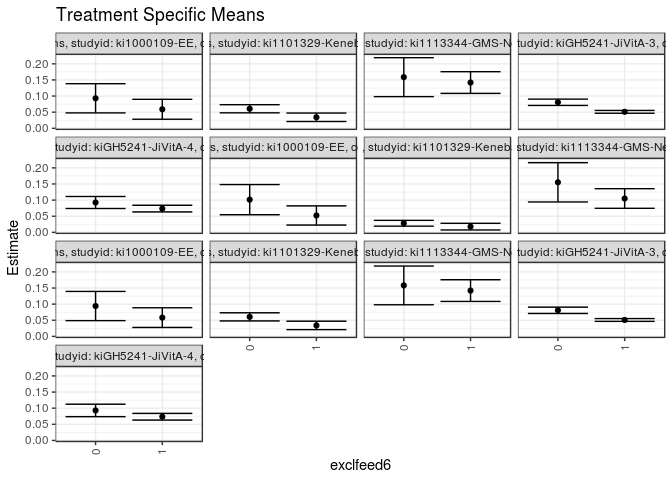

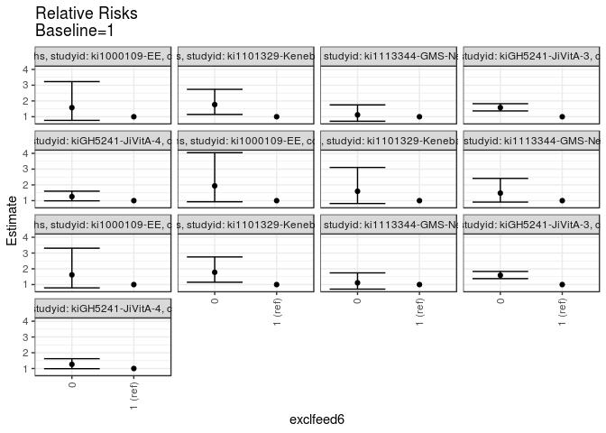

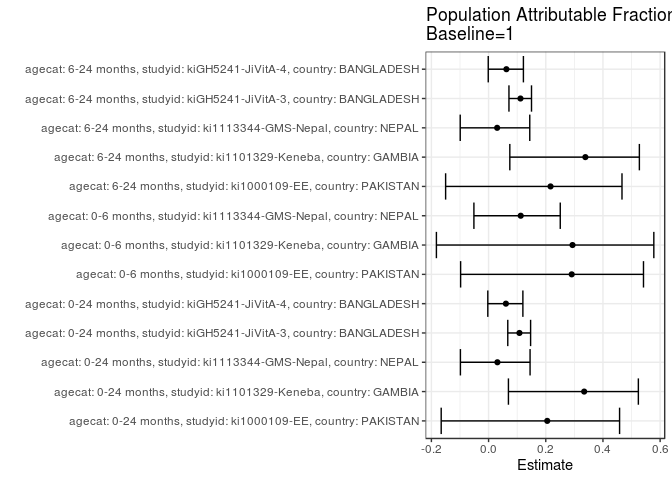

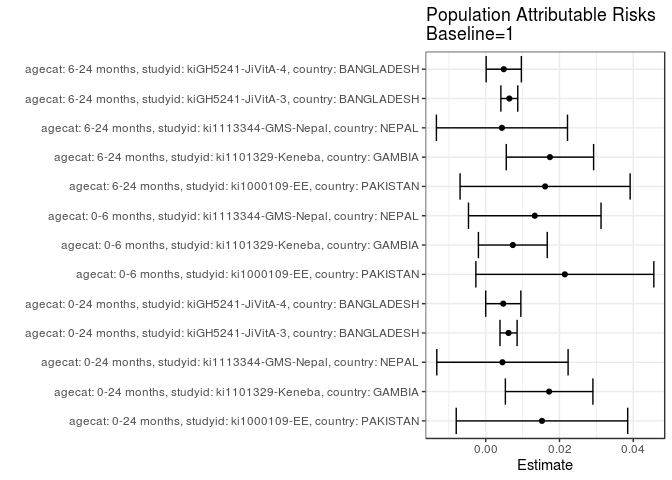

## Results Table

### Parameter: TSM

| agecat | studyid | country | intervention_level | baseline_level | estimate | ci_lower | ci_upper |
| --- | --- | --- | --- | --- | --- | --- | --- |
| 0-24 months | ki1000109-EE | PAKISTAN | 1 | NA | 0.0590271 | 0.0281031 | 0.0899511 |
| 0-24 months | ki1000109-EE | PAKISTAN | 0 | NA | 0.0930467 | 0.0477426 | 0.1383509 |
| 0-24 months | ki1101329-Keneba | GAMBIA | 1 | NA | 0.0342248 | 0.0211277 | 0.0473218 |
| 0-24 months | ki1101329-Keneba | GAMBIA | 0 | NA | 0.0605965 | 0.0479776 | 0.0732154 |
| 0-24 months | ki1113344-GMS-Nepal | NEPAL | 1 | NA | 0.1419019 | 0.1082564 | 0.1755475 |
| 0-24 months | ki1113344-GMS-Nepal | NEPAL | 0 | NA | 0.1585798 | 0.0982130 | 0.2189466 |
| 0-24 months | kiGH5241-JiVitA-3 | BANGLADESH | 1 | NA | 0.0511053 | 0.0467589 | 0.0554517 |
| 0-24 months | kiGH5241-JiVitA-3 | BANGLADESH | 0 | NA | 0.0807409 | 0.0709516 | 0.0905302 |
| 0-24 months | kiGH5241-JiVitA-4 | BANGLADESH | 1 | NA | 0.0736171 | 0.0632818 | 0.0839523 |
| 0-24 months | kiGH5241-JiVitA-4 | BANGLADESH | 0 | NA | 0.0925626 | 0.0739764 | 0.1111488 |
| 0-6 months | ki1000109-EE | PAKISTAN | 1 | NA | 0.0523217 | 0.0225453 | 0.0820980 |
| 0-6 months | ki1000109-EE | PAKISTAN | 0 | NA | 0.1013948 | 0.0545978 | 0.1481918 |
| 0-6 months | ki1101329-Keneba | GAMBIA | 1 | NA | 0.0176800 | 0.0073142 | 0.0280458 |
| 0-6 months | ki1101329-Keneba | GAMBIA | 0 | NA | 0.0281701 | 0.0191950 | 0.0371452 |
| 0-6 months | ki1113344-GMS-Nepal | NEPAL | 1 | NA | 0.1049087 | 0.0744992 | 0.1353182 |
| 0-6 months | ki1113344-GMS-Nepal | NEPAL | 0 | NA | 0.1551688 | 0.0942569 | 0.2160807 |
| 6-24 months | ki1000109-EE | PAKISTAN | 1 | NA | 0.0581758 | 0.0276169 | 0.0887348 |
| 6-24 months | ki1000109-EE | PAKISTAN | 0 | NA | 0.0941274 | 0.0488478 | 0.1394069 |
| 6-24 months | ki1101329-Keneba | GAMBIA | 1 | NA | 0.0340082 | 0.0209482 | 0.0470683 |
| 6-24 months | ki1101329-Keneba | GAMBIA | 0 | NA | 0.0604907 | 0.0478715 | 0.0731098 |
| 6-24 months | ki1113344-GMS-Nepal | NEPAL | 1 | NA | 0.1420342 | 0.1083975 | 0.1756709 |
| 6-24 months | ki1113344-GMS-Nepal | NEPAL | 0 | NA | 0.1581400 | 0.0980416 | 0.2182384 |
| 6-24 months | kiGH5241-JiVitA-3 | BANGLADESH | 1 | NA | 0.0508976 | 0.0465584 | 0.0552367 |
| 6-24 months | kiGH5241-JiVitA-3 | BANGLADESH | 0 | NA | 0.0808855 | 0.0710437 | 0.0907272 |
| 6-24 months | kiGH5241-JiVitA-4 | BANGLADESH | 1 | NA | 0.0734828 | 0.0631400 | 0.0838257 |
| 6-24 months | kiGH5241-JiVitA-4 | BANGLADESH | 0 | NA | 0.0930020 | 0.0736529 | 0.1123512 |

### Parameter: E(Y)

| agecat | studyid | country | intervention_level | baseline_level | estimate | ci_lower | ci_upper |
| --- | --- | --- | --- | --- | --- | --- | --- |
| 0-24 months | ki1000109-EE | PAKISTAN | NA | NA | 0.0742706 | 0.0477670 | 0.1007741 |
| 0-24 months | ki1101329-Keneba | GAMBIA | NA | NA | 0.0514151 | 0.0420121 | 0.0608181 |
| 0-24 months | ki1113344-GMS-Nepal | NEPAL | NA | NA | 0.1464286 | 0.1171213 | 0.1757358 |
| 0-24 months | kiGH5241-JiVitA-3 | BANGLADESH | NA | NA | 0.0572887 | 0.0532017 | 0.0613756 |
| 0-24 months | kiGH5241-JiVitA-4 | BANGLADESH | NA | NA | 0.0783679 | 0.0692461 | 0.0874896 |
| 0-6 months | ki1000109-EE | PAKISTAN | NA | NA | 0.0737705 | 0.0469540 | 0.1005870 |
| 0-6 months | ki1101329-Keneba | GAMBIA | NA | NA | 0.0250261 | 0.0180336 | 0.0320185 |
| 0-6 months | ki1113344-GMS-Nepal | NEPAL | NA | NA | 0.1181989 | 0.0907652 | 0.1456326 |
| 6-24 months | ki1000109-EE | PAKISTAN | NA | NA | 0.0742706 | 0.0477670 | 0.1007741 |
| 6-24 months | ki1101329-Keneba | GAMBIA | NA | NA | 0.0514151 | 0.0420121 | 0.0608181 |
| 6-24 months | ki1113344-GMS-Nepal | NEPAL | NA | NA | 0.1464286 | 0.1171213 | 0.1757358 |
| 6-24 months | kiGH5241-JiVitA-3 | BANGLADESH | NA | NA | 0.0572887 | 0.0532017 | 0.0613756 |
| 6-24 months | kiGH5241-JiVitA-4 | BANGLADESH | NA | NA | 0.0783679 | 0.0692461 | 0.0874896 |

### Parameter: RR

| agecat | studyid | country | intervention_level | baseline_level | estimate | ci_lower | ci_upper |
| --- | --- | --- | --- | --- | --- | --- | --- |
| 0-24 months | ki1000109-EE | PAKISTAN | 1 | 1 | 1.000000 | 1.0000000 | 1.000000 |
| 0-24 months | ki1000109-EE | PAKISTAN | 0 | 1 | 1.576340 | 0.7700635 | 3.226809 |
| 0-24 months | ki1101329-Keneba | GAMBIA | 1 | 1 | 1.000000 | 1.0000000 | 1.000000 |
| 0-24 months | ki1101329-Keneba | GAMBIA | 0 | 1 | 1.770547 | 1.1450856 | 2.737643 |
| 0-24 months | ki1113344-GMS-Nepal | NEPAL | 1 | 1 | 1.000000 | 1.0000000 | 1.000000 |
| 0-24 months | ki1113344-GMS-Nepal | NEPAL | 0 | 1 | 1.117531 | 0.7134321 | 1.750518 |
| 0-24 months | kiGH5241-JiVitA-3 | BANGLADESH | 1 | 1 | 1.000000 | 1.0000000 | 1.000000 |
| 0-24 months | kiGH5241-JiVitA-3 | BANGLADESH | 0 | 1 | 1.579894 | 1.3677507 | 1.824941 |
| 0-24 months | kiGH5241-JiVitA-4 | BANGLADESH | 1 | 1 | 1.000000 | 1.0000000 | 1.000000 |
| 0-24 months | kiGH5241-JiVitA-4 | BANGLADESH | 0 | 1 | 1.257353 | 0.9878546 | 1.600373 |
| 0-6 months | ki1000109-EE | PAKISTAN | 1 | 1 | 1.000000 | 1.0000000 | 1.000000 |
| 0-6 months | ki1000109-EE | PAKISTAN | 0 | 1 | 1.937912 | 0.9290837 | 4.042159 |
| 0-6 months | ki1101329-Keneba | GAMBIA | 1 | 1 | 1.000000 | 1.0000000 | 1.000000 |
| 0-6 months | ki1101329-Keneba | GAMBIA | 0 | 1 | 1.593331 | 0.8173173 | 3.106144 |
| 0-6 months | ki1113344-GMS-Nepal | NEPAL | 1 | 1 | 1.000000 | 1.0000000 | 1.000000 |
| 0-6 months | ki1113344-GMS-Nepal | NEPAL | 0 | 1 | 1.479084 | 0.9076553 | 2.410265 |
| 6-24 months | ki1000109-EE | PAKISTAN | 1 | 1 | 1.000000 | 1.0000000 | 1.000000 |
| 6-24 months | ki1000109-EE | PAKISTAN | 0 | 1 | 1.617980 | 0.7914404 | 3.307717 |
| 6-24 months | ki1101329-Keneba | GAMBIA | 1 | 1 | 1.000000 | 1.0000000 | 1.000000 |
| 6-24 months | ki1101329-Keneba | GAMBIA | 0 | 1 | 1.778706 | 1.1488926 | 2.753778 |
| 6-24 months | ki1113344-GMS-Nepal | NEPAL | 1 | 1 | 1.000000 | 1.0000000 | 1.000000 |
| 6-24 months | ki1113344-GMS-Nepal | NEPAL | 0 | 1 | 1.113393 | 0.7113999 | 1.742543 |
| 6-24 months | kiGH5241-JiVitA-3 | BANGLADESH | 1 | 1 | 1.000000 | 1.0000000 | 1.000000 |
| 6-24 months | kiGH5241-JiVitA-3 | BANGLADESH | 0 | 1 | 1.589181 | 1.3773539 | 1.833585 |
| 6-24 months | kiGH5241-JiVitA-4 | BANGLADESH | 1 | 1 | 1.000000 | 1.0000000 | 1.000000 |
| 6-24 months | kiGH5241-JiVitA-4 | BANGLADESH | 0 | 1 | 1.265630 | 0.9880541 | 1.621185 |

### Parameter: PAR

| agecat | studyid | country | intervention_level | baseline_level | estimate | ci_lower | ci_upper |
| --- | --- | --- | --- | --- | --- | --- | --- |
| 0-24 months | ki1000109-EE | PAKISTAN | 1 | NA | 0.0152435 | -0.0080051 | 0.0384921 |
| 0-24 months | ki1101329-Keneba | GAMBIA | 1 | NA | 0.0171903 | 0.0053196 | 0.0290611 |
| 0-24 months | ki1113344-GMS-Nepal | NEPAL | 1 | NA | 0.0045266 | -0.0132785 | 0.0223317 |
| 0-24 months | kiGH5241-JiVitA-3 | BANGLADESH | 1 | NA | 0.0061834 | 0.0038653 | 0.0085016 |
| 0-24 months | kiGH5241-JiVitA-4 | BANGLADESH | 1 | NA | 0.0047508 | -0.0000145 | 0.0095161 |
| 0-6 months | ki1000109-EE | PAKISTAN | 1 | NA | 0.0214488 | -0.0026811 | 0.0455788 |
| 0-6 months | ki1101329-Keneba | GAMBIA | 1 | NA | 0.0073461 | -0.0019868 | 0.0166790 |
| 0-6 months | ki1113344-GMS-Nepal | NEPAL | 1 | NA | 0.0132902 | -0.0046825 | 0.0312628 |
| 6-24 months | ki1000109-EE | PAKISTAN | 1 | NA | 0.0160947 | -0.0069648 | 0.0391542 |
| 6-24 months | ki1101329-Keneba | GAMBIA | 1 | NA | 0.0174069 | 0.0055664 | 0.0292473 |
| 6-24 months | ki1113344-GMS-Nepal | NEPAL | 1 | NA | 0.0043943 | -0.0133813 | 0.0221700 |
| 6-24 months | kiGH5241-JiVitA-3 | BANGLADESH | 1 | NA | 0.0063911 | 0.0041020 | 0.0086801 |
| 6-24 months | kiGH5241-JiVitA-4 | BANGLADESH | 1 | NA | 0.0048851 | 0.0001099 | 0.0096602 |

### Parameter: PAF

| agecat | studyid | country | intervention_level | baseline_level | estimate | ci_lower | ci_upper |
| --- | --- | --- | --- | --- | --- | --- | --- |
| 0-24 months | ki1000109-EE | PAKISTAN | 1 | NA | 0.2052427 | -0.1657248 | 0.4581575 |
| 0-24 months | ki1101329-Keneba | GAMBIA | 1 | NA | 0.3343440 | 0.0694278 | 0.5238436 |
| 0-24 months | ki1113344-GMS-Nepal | NEPAL | 1 | NA | 0.0309136 | -0.0985233 | 0.1450992 |
| 0-24 months | kiGH5241-JiVitA-3 | BANGLADESH | 1 | NA | 0.1079343 | 0.0671303 | 0.1469535 |
| 0-24 months | kiGH5241-JiVitA-4 | BANGLADESH | 1 | NA | 0.0606217 | -0.0027093 | 0.1199528 |
| 0-6 months | ki1000109-EE | PAKISTAN | 1 | NA | 0.2907506 | -0.0978059 | 0.5417818 |
| 0-6 months | ki1101329-Keneba | GAMBIA | 1 | NA | 0.2935375 | -0.1824792 | 0.5779298 |
| 0-6 months | ki1113344-GMS-Nepal | NEPAL | 1 | NA | 0.1124391 | -0.0513257 | 0.2506942 |
| 6-24 months | ki1000109-EE | PAKISTAN | 1 | NA | 0.2167040 | -0.1502534 | 0.4665935 |
| 6-24 months | ki1101329-Keneba | GAMBIA | 1 | NA | 0.3385554 | 0.0742870 | 0.5273817 |
| 6-24 months | ki1113344-GMS-Nepal | NEPAL | 1 | NA | 0.0300102 | -0.0991920 | 0.1440255 |
| 6-24 months | kiGH5241-JiVitA-3 | BANGLADESH | 1 | NA | 0.1115593 | 0.0712512 | 0.1501180 |
| 6-24 months | kiGH5241-JiVitA-4 | BANGLADESH | 1 | NA | 0.0623349 | -0.0011656 | 0.1218078 |